# Assignment 2

October 11, 2020

```r
library(tidyverse)
library(sf)
library(tigris)
library(leaflet)
library(censusapi)
library(devtools)
library(tidycensus)

Sys.setenv(CENSUS_KEY="c8aa67e4086b4b5ce3a8717f59faa9a28f611dab")

acs_vars_2018_5yr <-
  listCensusMetadata(
    name = "2018/acs/acs5",
    type = "variables"
  )
saveRDS(acs_vars_2018_5yr, "acs_vars_2018_5yr.rds")
```

PART 1

```r
census_race_labels <-
  c(
    "White Alone",
    "Black or African American",
    "American Indian and Alaska Native Alone",
    "Asian Alone",
    "Native Hawaiian and Other Pacific Islander Alone)",
    "Some Other Race Alone",
    "Two or More Races"
  )
```

```r
Alameda_county_education_race <-
  1:7 %>%
  map_dfr(function(x){
    getCensus(
      name = "acs/acs5",
      vintage = 2018,
      region = "county:001",
      regionin = "state:06",
      vars = paste0("group(C15002",LETTERS[x],")")
    ) %>%
      select(!c(GEO_ID,state,NAME) & !ends_with(c("EA","MA","M"))) %>%
      pivot_longer(
        ends_with("E"),
        names_to = "variable",
        values_to = "estimate"
      ) %>%
      left_join(
        acs_vars_2018_5yr %>%
          select(name, label),
        by = c("variable" = "name")
      ) %>%
      select(-variable) %>%
      separate(
        label,
        into = c(NA,NA, "sex", "educational_attainment"),
        sep = "!!"
      ) %>%
      filter(!is.na(educational_attainment)) %>%
      mutate(race = census_race_labels[x])
  })
```

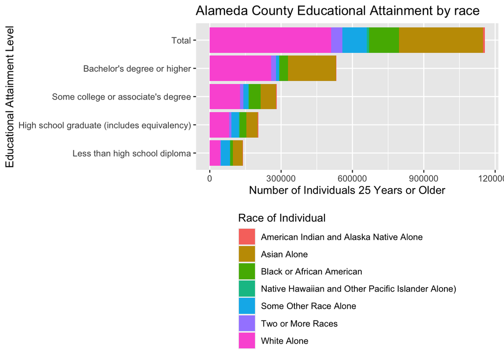

```r
Alameda_race_total <-
  Alameda_county_education_race %>%
  group_by(race) %>%
  summarize(estimate = sum(estimate)) %>%
  mutate(educational_attainment = "Total")


Alameda_county_education_race %>%
  group_by(educational_attainment, race) %>%
  summarize(estimate = sum(estimate)) %>%
  rbind(Alameda_race_total) %>%
  ggplot() +
  geom_bar(
    aes(
      x = educational_attainment %>%
        factor(levels = c(Alameda_county_education_race$educational_attainment[1:4], "Total")),
      y = estimate,
      fill = race
    ),
    stat = "identity",
    position = "stack",
  ) +
  labs(
    x = "Educational Attainment Level",
    y = "Number of Individuals 25 Years or Older",
    title = "Alameda County Educational Attainment by race",
    fill = "Race of Individual"
  ) +
  coord_flip() +
  theme(
    legend.position = "bottom",
    legend.direction = "vertical"
  )
```

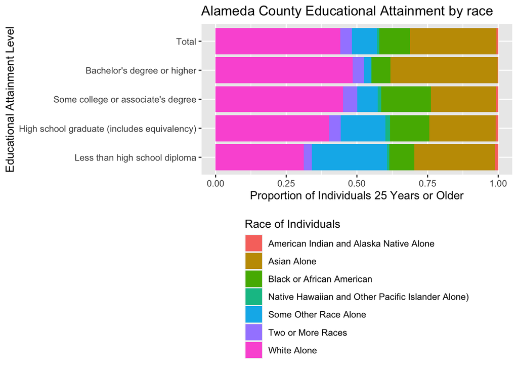

```r
Alameda_county_education_race %>%
  group_by(educational_attainment, race) %>%
  summarize(estimate = sum(estimate)) %>%
  rbind(Alameda_race_total) %>%
  ggplot() +
  geom_bar(
    aes(
      x = educational_attainment %>%
        factor(levels = c(Alameda_county_education_race$educational_attainment[1:4], "Total")),
      y = estimate,
      fill = race
    ),
    stat = "identity",
    position = "fill"
  ) +
  labs(
    x = "Educational Attainment Level",
    y = "Proportion of Individuals 25 Years or Older",
    title = "Alameda County Educational Attainment by race",
    fill = "Race of Individuals"
  ) +
  coord_flip() +
  theme(
    legend.position = "bottom",
    legend.direction = "vertical"
  )
```

```r
((sum(Alameda_race_total$estimate[1:6])/sum(Alameda_race_total$estimate))*100) %>% round()
```

```
## [1] 56
```

```r
#This shows that the overall population of Alameda County is 56% non-White.

((Alameda_county_education_race %>%
    filter(educational_attainment
           %in% Alameda_county_education_race$educational_attainment[1:3]) %>%
    filter(race != "White Alone") %>%
    pull(estimate) %>%
    sum()) /
    (Alameda_county_education_race %>%
       filter(educational_attainment
              %in% Alameda_county_education_race$educational_attainment[1:3]) %>%
       pull(estimate) %>%
       sum()) * 100) %>%
    round()
```

```
## [1] 60
```

```r
# This indicates that the subpopulation of individuals with an education level lower than "bachelor's degree or higher" is 60% non-White.

((Alameda_county_education_race %>%
    filter(educational_attainment
           %in% Alameda_county_education_race$educational_attainment[4]) %>%
    filter(race != "White Alone") %>%
    pull(estimate) %>%
    sum()) /
    (Alameda_county_education_race %>%
       filter(educational_attainment
              %in% Alameda_county_education_race$educational_attainment[4]) %>%
       pull(estimate) %>%
       sum()) * 100) %>%
    round()
```

```
## [1] 52
```

```r
#Non-White individuals make up only 52% of those with a "bachelor's degree or higher."
```

This analysis indicates that there are disparities between races and educational attainment in Alameda County (for individuals 25 years or older). More specifically, residents who are “White Alone” or “Asian Alone” are overrepresented in the highest educational attainment level and are underrepresented in the lower educational attainment levels. Conversely, residents who are “Black of African American” or “Some Other Race Alone” are underrepresented in the highest educational attainment level and are overrepresented in the lower educational attainment levels. While the overall population of Alameda County is 56% non-White, the subpopulation of individuals without a bachelor’s degree or higher is 60% non-White. Moreover, non-White Individuals make up only 52% of those with a bachelor’s degree or higher. This analysis suggests that there is disproportionate educational attainment by race in Alameda County.

PART 2

```r
temp <- tempfile()
download.file("https://www2.census.gov/programs-surveys/acs/data/pums/2018/5-Year/csv_hca.zip",destfile = temp, mode = "wb")

pums_hca_2018_5yr <- read_csv(unzip(temp,"psam_h06.csv"))

unlink(temp)
```

```r
census_api_key("c8aa67e4086b4b5ce3a8717f59faa9a28f611dab", install = TRUE, overwrite = TRUE)
```

```
## [1] "c8aa67e4086b4b5ce3a8717f59faa9a28f611dab"
```

```r
readRenviron("~/.Renviron")

pums_vars_2018 <-
  pums_variables %>%
  filter(year == 2018, survey == "acs5")
```

```r
ca_pums <- get_pums(
  variables = c(
    "PUMA",
    "NP",
    "ACCESS",
    "SCHG"
  ),
  state = "CA",
  year = 2018,
  survey = "acs1",
  recode = T
)
saveRDS(ca_pums, "ca_pums.rds")
```

```r
ca_counties <- counties("CA", cb = T, progress_bar = F)

Alameda_county <-
  ca_counties %>%
  filter(NAME == "Alameda")
```

```r
ca_pumas <-
  pumas("CA", cb = T, progress_bar = F)

Alameda_pumas <-
  ca_pumas %>%
  st_centroid() %>%
  .[Alameda_county, ] %>%
  st_set_geometry(NULL) %>%
  left_join(ca_pumas %>% select(GEOID10)) %>%
  st_as_sf()

Alameda_pums <-
  ca_pums %>%
  filter(PUMA %in% Alameda_pumas$PUMACE10) %>%
  mutate(SCHG = as.numeric(SCHG)) %>%
  filter(SCHG %in% c(2:14)) %>%
  mutate(
  num_students_no_internet = ifelse(
    (ACCESS == "3"),
    PWGTP,
    0
  ))
```

```r
student_internet <-
  Alameda_pums %>%
  summarize(
    perc_students_no_internet =
      sum(num_students_no_internet, na.rm = T)/sum(PWGTP, na.rm = T) * 100,
    total_student_no_internet =sum(num_students_no_internet, na.rm =T)
  ) %>%
  print(student_internet)
```

```
## # A tibble: 1 x 2
##   perc_students_no_internet total_student_no_internet
##                       <dbl>                     <dbl>
## 1                      2.39                      5836
```

```r
grouped_by_puma <-
  Alameda_pums %>%
  group_by(PUMA) %>%
  summarize(
    perc_students_no_internet =
      sum(num_students_no_internet, na.rm = T)/sum(PWGTP, na.rm = T) * 100,
    total_student_no_internet =sum(num_students_no_internet, na.rm =T)
  ) %>%
  left_join(
    Alameda_pumas %>%
      select(PUMACE10),
    by = c("PUMA" = "PUMACE10")
  ) %>%
  st_as_sf()


pums_pal <- colorNumeric(
  palette = "Oranges",
  domain = grouped_by_puma$perc_students_no_internet
)

leaflet() %>%
  addTiles() %>%
  addPolygons(
    data = grouped_by_puma %>%
       st_transform(4326),
    fillColor = ~pums_pal(perc_students_no_internet),
    color = "white",
    opacity = 0.5,
    fillOpacity = 0.5,
    weight = 1,
    label = ~paste0(
      round(perc_students_no_internet),
      "% of Students Grades K-12 Without Home Internet Access in ",
      PUMA
    ),
    highlightOptions = highlightOptions(
      weight = 2,
      opacity = 1
    )
  ) %>%
  addLegend(
    data = grouped_by_puma,
    pal = pums_pal,
    values = ~perc_students_no_internet,
    title = "% of Students Grades K-12 <br> Without Home Internet Access"
  )
```

[interactive chart not shown]

One important assumption in this analysis is that the data provides an accurate representation of students’ current situation in Alameda County. Because this analysis is based on ACS 2018 1-year data, it doesn’t capture the affects of the COVID-19 pandemic on remote learning. This data set also doesn’t provide direct insight into additional challenges with remote learning and internet such as the quality of internet access. For example, with more people both working and learning from home, it seems likely that households with internet access could still experience additional internet constraints such as bandwidth issues, and these types of challenges are not reflected in this data set. Moreover, internet access is only valuable to students if they have a device, such as a laptop, to utilize for school work. So, access to an electronic device in addition to internet is another assumption made in this analysis.

PART 3

```r
acs_vars_2019_1yr <-
  listCensusMetadata(
    name = "2019/acs/acs1",
    type = "variables"
  )
```

```r
ac_mobility_current_19 <-
    getCensus(
    name = "acs/acs1",
    vintage = 2019,
    region = "county:001",
    regionin = "state:06",
    vars = c("group(B07009)")
  ) %>%
  select(!c(GEO_ID,state,NAME) & !ends_with(c("EA","MA","M"))) %>%
  pivot_longer(
    ends_with("E"),
    names_to = "variable",
    values_to = "estimate"
  ) %>%
  left_join(
    acs_vars_2019_1yr %>%
      select(name, label),
    by = c("variable" = "name")
  ) %>%
  select(-variable) %>%
  separate(
    label,
    into=c(NA,NA,"mobility", "educational_attainment"),
    sep= "!!"
  ) %>%
  mutate(
    mobility = ifelse(
      mobility %in% c("Same house 1 year ago:", "Moved within same county:"),
      "Here since last year",
      "Inflow"
    )
  ) %>%
  filter(!is.na(educational_attainment)) %>%
  group_by(mobility, educational_attainment) %>%
  summarize(estimate = sum(estimate))
```

```r
ac_mobility_lastyear_19 <-
  getCensus(
    name = "acs/acs1",
    vintage = 2019,
    region = "county:001",
    regionin = "state:06",
    vars = c("group(B07409)")
  ) %>%
  select(!c(GEO_ID,state,NAME) & !ends_with(c("EA","MA","M"))) %>%
  pivot_longer(
    ends_with("E"),
    names_to = "variable",
    values_to = "estimate"
  ) %>%
  left_join(
    acs_vars_2019_1yr %>%
      select(name, label),
    by = c("variable" = "name")
  ) %>%
  select(-variable) %>%
  separate(
    label,
    into = c(NA,NA,"mobility", "educational_attainment"),
    sep = "!!"
  ) %>%
  mutate(
    mobility = ifelse(
      mobility %in% c("Same house:", "Moved within same county:"),
      "Here since last year",
      "Outflow"
    )
  ) %>%
  filter(!is.na(educational_attainment)) %>%
  group_by(mobility, educational_attainment) %>%
  summarize(estimate = sum(estimate))
```

```r
ac_mobility_current_18 <-
  getCensus(
    name = "acs/acs1",
    vintage = 2018,
    region = "county:001",
    regionin = "state:06",
    vars = c("group(B07009)")
  ) %>%
  select(!c(GEO_ID,state,NAME) & !ends_with(c("EA","MA","M"))) %>%
  pivot_longer(
    ends_with("E"),
    names_to = "variable",
    values_to = "estimate"
  ) %>%
  left_join(
    acs_vars_2019_1yr %>%
      select(name, label),
    by = c("variable" = "name")
  ) %>%
  select(-variable) %>%
  separate(
    label,
    into = c(NA,NA,"mobility", "educational_attainment"),
    sep = "!!"
  ) %>%
  mutate(
    mobility = "Here last year"
  ) %>%
  filter(!is.na(educational_attainment)) %>%
  group_by(mobility, educational_attainment) %>%
  summarize(estimate = sum(estimate))
```

```r
ac_migration_flow_19 <-
   rbind(
    ac_mobility_current_18,
    ac_mobility_lastyear_19 %>%
      filter(mobility == "Outflow"),
    ac_mobility_current_19 %>%
      filter(mobility == "Inflow"),
    ac_mobility_current_19 %>%
      group_by(educational_attainment) %>%
      summarize(estimate = sum(estimate)) %>%
      mutate(mobility = "Here this year")
  ) %>%
  pivot_wider(
    names_from = mobility,
    values_from = estimate
  ) %>%
  mutate(
    `External net` = Inflow - Outflow,
    `Internal net` = `Here this year` - `Here last year` - `External net`,
     educational_attainment = educational_attainment %>% factor(levels = c(
      "Less than high school graduate",
      "High school graduate (includes equivalency)",
      "Some college or associate's degree",
      "Bachelor's degree",
      "Graduate or professional degree"))
    ) %>%
  arrange(educational_attainment) %>%
  select(
    `Educational Attainment` = educational_attainment,
    `Internal net`,
    `External net`,
    `Here last year`,
    `Here this year`,
    Outflow,
    Inflow
  )


ac_migration_flow_19
```

```
## # A tibble: 5 x 7
##   `Educational At… `Internal net` `External net` `Here last year`
##   <fct>                     <dbl>          <dbl>            <dbl>
## 1 Less than high …          -1335           1174           124223
## 2 High school gra…          -7992            -15           214368
## 3 Some college or…          -8890          -6028           274788
## 4 Bachelor's degr…          18271           6034           326386
## 5 Graduate or pro…           6148           1515           246460
## # … with 3 more variables: `Here this year` <dbl>, Outflow <dbl>, Inflow <dbl>
```

The results of this migration analysis show that there is a positive external net flow for the highest education levels (bachelor’s degree or graduate/professional degree). Interestingly, there is also a positive net external flow for people in the “less than high school graduate” category, but this is largely outweighed by the positive external flow of college-educated residents, especially those with a bachelor’s degree. There is a negative external net flow for those in the “high school graduate” or “some college or associate’s degree” category. This division among education levels points to an interesting trend: overall, Alameda county is gaining mostly college-educated residents and losing residents with lower education levels. Similarly, there is a large positive internal net flow in the “bachelor’s degree” and “graduate or professional degree” categories, and this trend is especially large for the “bachelor’s degree” category. This analysis indicates that many residents already living in Alameda County are becoming more educated and thus leaving their old educational attainment categories.